# Cyclistic

Praveer Tiwari

13/07/2023

## Cyclistic

Install needed packages

```r
install.packages("tidyverse", repos = "http://cran.us.r-project.org")
install.packages("lubridate", repos = "http://cran.us.r-project.org")
library(tidyverse)
library(lubridate)
```

Import data

```r
  setwd("~")
  trip_data_2020_12 <- read.csv("202012-divvy-tripdata.csv")
  trip_data_2021_01 <- read.csv("202101-divvy-tripdata.csv")
  trip_data_2021_02 <- read.csv("202102-divvy-tripdata.csv")
  trip_data_2021_03 <- read.csv("202103-divvy-tripdata.csv")
  trip_data_2021_04 <- read.csv("202104-divvy-tripdata.csv")
  trip_data_2021_05 <- read.csv("202105-divvy-tripdata.csv")
  trip_data_2021_06 <- read.csv("202106-divvy-tripdata.csv")
  trip_data_2021_07 <- read.csv("202107-divvy-tripdata.csv")
  trip_data_2021_08 <- read.csv("202108-divvy-tripdata.csv")
  trip_data_2021_09 <- read.csv("202109-divvy-tripdata.csv")
  trip_data_2021_10 <- read.csv("202110-divvy-tripdata.csv")
  trip_data_2021_11 <- read.csv("202111-divvy-tripdata.csv")
```

Check column names to ensure we can join all the data

```r
  colnames(trip_data_2020_12)
```

```
##  [1] "ride_id"            "rideable_type"      "started_at"
##  [4] "ended_at"           "start_station_name" "start_station_id"
##  [7] "end_station_name"   "end_station_id"     "start_lat"
## [10] "start_lng"          "end_lat"            "end_lng"
## [13] "member_casual"
```

```r
  colnames(trip_data_2021_01)
```

```
##  [1] "ride_id"            "rideable_type"      "started_at"
##  [4] "ended_at"           "start_station_name" "start_station_id"
##  [7] "end_station_name"   "end_station_id"     "start_lat"
## [10] "start_lng"          "end_lat"            "end_lng"
## [13] "member_casual"
```

```r
  colnames(trip_data_2021_02)
```

```
##  [1] "ride_id"            "rideable_type"      "started_at"
##  [4] "ended_at"           "start_station_name" "start_station_id"
##  [7] "end_station_name"   "end_station_id"     "start_lat"
## [10] "start_lng"          "end_lat"            "end_lng"
## [13] "member_casual"
```

```r
  colnames(trip_data_2021_03)
```

```
##  [1] "ride_id"            "rideable_type"      "started_at"
##  [4] "ended_at"           "start_station_name" "start_station_id"
##  [7] "end_station_name"   "end_station_id"     "start_lat"
## [10] "start_lng"          "end_lat"            "end_lng"
## [13] "member_casual"
```

```r
  colnames(trip_data_2021_04)
```

```
##  [1] "ride_id"            "rideable_type"      "started_at"
##  [4] "ended_at"           "start_station_name" "start_station_id"
##  [7] "end_station_name"   "end_station_id"     "start_lat"
## [10] "start_lng"          "end_lat"            "end_lng"
## [13] "member_casual"
```

```r
  colnames(trip_data_2021_05)
```

```
##  [1] "ride_id"            "rideable_type"      "started_at"
##  [4] "ended_at"           "start_station_name" "start_station_id"
##  [7] "end_station_name"   "end_station_id"     "start_lat"
## [10] "start_lng"          "end_lat"            "end_lng"
## [13] "member_casual"
```

```r
  colnames(trip_data_2021_06)
```

```
##  [1] "ride_id"            "rideable_type"      "started_at"
##  [4] "ended_at"           "start_station_name" "start_station_id"
##  [7] "end_station_name"   "end_station_id"     "start_lat"
## [10] "start_lng"          "end_lat"            "end_lng"
## [13] "member_casual"
```

```r
  colnames(trip_data_2021_07)
```

```
##  [1] "ride_id"            "rideable_type"      "started_at"
##  [4] "ended_at"           "start_station_name" "start_station_id"
##  [7] "end_station_name"   "end_station_id"     "start_lat"
## [10] "start_lng"          "end_lat"            "end_lng"
## [13] "member_casual"
```

```r
  colnames(trip_data_2021_08)
```

```
##  [1] "ride_id"            "rideable_type"      "started_at"
##  [4] "ended_at"           "start_station_name" "start_station_id"
##  [7] "end_station_name"   "end_station_id"     "start_lat"
## [10] "start_lng"          "end_lat"            "end_lng"
## [13] "member_casual"
```

```r
  colnames(trip_data_2021_09)
```

```
##  [1] "ride_id"            "rideable_type"      "started_at"
##  [4] "ended_at"           "start_station_name" "start_station_id"
##  [7] "end_station_name"   "end_station_id"     "start_lat"
## [10] "start_lng"          "end_lat"            "end_lng"
## [13] "member_casual"
```

```r
  colnames(trip_data_2021_10)
```

```
##  [1] "ride_id"            "rideable_type"      "started_at"
##  [4] "ended_at"           "start_station_name" "start_station_id"
##  [7] "end_station_name"   "end_station_id"     "start_lat"
## [10] "start_lng"          "end_lat"            "end_lng"
## [13] "member_casual"
```

```r
  colnames(trip_data_2021_11)
```

```
##  [1] "ride_id"            "rideable_type"      "started_at"
##  [4] "ended_at"           "start_station_name" "start_station_id"
##  [7] "end_station_name"   "end_station_id"     "start_lat"
## [10] "start_lng"          "end_lat"            "end_lng"
## [13] "member_casual"
```

Combine data into one set.

```r
all_trips <- rbind(trip_data_2020_12, trip_data_2021_01, trip_data_2021_02, trip_data_2021_03, trip_data_2021_04, trip_data_2021_05, trip_data_2021_06, trip_data_2021_07, trip_data_2021_08, trip_data_2021_09, trip_data_2021_10, trip_data_2021_11)
```

Inspect data to find cleaning opportunities

```r
colnames(all_trips)
```

```
##  [1] "ride_id"            "rideable_type"      "started_at"
##  [4] "ended_at"           "start_station_name" "start_station_id"
##  [7] "end_station_name"   "end_station_id"     "start_lat"
## [10] "start_lng"          "end_lat"            "end_lng"
## [13] "member_casual"
```

```r
nrow(all_trips)
```

```
## [1] 5479096
```

```r
dim(all_trips)
```

```
## [1] 5479096      13
```

```r
head(all_trips)
```

```
##            ride_id rideable_type          started_at            ended_at
## 1 70B6A9A437D4C30D  classic_bike 2020-12-27 12:44:29 2020-12-27 12:55:06
## 2 158A465D4E74C54A electric_bike 2020-12-18 17:37:15 2020-12-18 17:44:19
## 3 5262016E0F1F2F9A electric_bike 2020-12-15 15:04:33 2020-12-15 15:11:28
## 4 BE119628E44F871E electric_bike 2020-12-15 15:54:18 2020-12-15 16:00:11
## 5 69AF78D57854E110 electric_bike 2020-12-22 12:08:17 2020-12-22 12:10:59
## 6 C1DECC4AB488831C electric_bike 2020-12-22 13:26:37 2020-12-22 13:34:50
##           start_station_name start_station_id          end_station_name
## 1 Aberdeen St & Jackson Blvd            13157 Desplaines St & Kinzie St
## 2
## 3
## 4
## 5
## 6
##   end_station_id start_lat start_lng  end_lat   end_lng member_casual
## 1   TA1306000003  41.87773 -87.65479 41.88872 -87.64445        member
## 2                 41.93000 -87.70000 41.91000 -87.70000        member
## 3                 41.91000 -87.69000 41.93000 -87.70000        member
## 4                 41.92000 -87.70000 41.91000 -87.70000        member
## 5                 41.80000 -87.59000 41.80000 -87.59000        member
## 6                 41.80000 -87.59000 41.78000 -87.60000        member
```

```r
tail(all_trips)
```

```
##                  ride_id rideable_type          started_at            ended_at
## 5479091 2E383B4D2965B154 electric_bike 2021-11-04 16:59:24 2021-11-04 17:08:41
## 5479092 E00E9F3500D69BAA electric_bike 2021-11-29 00:39:13 2021-11-29 00:51:41
## 5479093 8EAA66CE314E5FF1 electric_bike 2021-11-03 13:56:33 2021-11-03 14:01:27
## 5479094 36C2DC8BB1E13491 electric_bike 2021-11-02 19:32:18 2021-11-02 19:36:16
## 5479095 8E42FE5C67DF6A96 electric_bike 2021-11-10 20:15:06 2021-11-10 20:22:01
## 5479096 4F15069E2D2519BC electric_bike 2021-11-30 20:18:00 2021-11-30 20:37:27
##                      start_station_name start_station_id end_station_name
## 5479091 Cityfront Plaza Dr & Pioneer Ct            13427
## 5479092         Logan Blvd & Elston Ave     TA1308000031
## 5479093         Logan Blvd & Elston Ave     TA1308000031
## 5479094         Logan Blvd & Elston Ave     TA1308000031
## 5479095         Logan Blvd & Elston Ave     TA1308000031
## 5479096         Ogden Ave & Chicago Ave     TA1305000020
##         end_station_id start_lat start_lng end_lat end_lng member_casual
## 5479091                 41.89021 -87.62151   41.88  -87.63        member
## 5479092                 41.92945 -87.68420   41.93  -87.72        member
## 5479093                 41.92944 -87.68418   41.94  -87.69        member
## 5479094                 41.92945 -87.68414   41.94  -87.69        member
## 5479095                 41.92943 -87.68418   41.94  -87.69        member
## 5479096                 41.89635 -87.65398   41.95  -87.70        member
```

```r
str(all_trips)
```

```
## 'data.frame':    5479096 obs. of  13 variables:
##  $ ride_id           : chr  "70B6A9A437D4C30D" "158A465D4E74C54A" "5262016E0F1F2F9A" "BE119628E44F871E" ...
##  $ rideable_type     : chr  "classic_bike" "electric_bike" "electric_bike" "electric_bike" ...
##  $ started_at        : chr  "2020-12-27 12:44:29" "2020-12-18 17:37:15" "2020-12-15 15:04:33" "2020-12-15 15:54:18" ...
##  $ ended_at          : chr  "2020-12-27 12:55:06" "2020-12-18 17:44:19" "2020-12-15 15:11:28" "2020-12-15 16:00:11" ...
##  $ start_station_name: chr  "Aberdeen St & Jackson Blvd" "" "" "" ...
##  $ start_station_id  : chr  "13157" "" "" "" ...
##  $ end_station_name  : chr  "Desplaines St & Kinzie St" "" "" "" ...
##  $ end_station_id    : chr  "TA1306000003" "" "" "" ...
##  $ start_lat         : num  41.9 41.9 41.9 41.9 41.8 ...
##  $ start_lng         : num  -87.7 -87.7 -87.7 -87.7 -87.6 ...
##  $ end_lat           : num  41.9 41.9 41.9 41.9 41.8 ...
##  $ end_lng           : num  -87.6 -87.7 -87.7 -87.7 -87.6 ...
##  $ member_casual     : chr  "member" "member" "member" "member" ...
```

```r
summary(all_trips)
```

```
##    ride_id          rideable_type       started_at          ended_at
##  Length:5479096     Length:5479096     Length:5479096     Length:5479096
##  Class :character   Class :character   Class :character   Class :character
##  Mode  :character   Mode  :character   Mode  :character   Mode  :character
##
##
##
##
##  start_station_name start_station_id   end_station_name   end_station_id
##  Length:5479096     Length:5479096     Length:5479096     Length:5479096
##  Class :character   Class :character   Class :character   Class :character
##  Mode  :character   Mode  :character   Mode  :character   Mode  :character
##
##
##
##
##    start_lat       start_lng         end_lat         end_lng
##  Min.   :41.64   Min.   :-87.84   Min.   :41.39   Min.   :-88.97
##  1st Qu.:41.88   1st Qu.:-87.66   1st Qu.:41.88   1st Qu.:-87.66
##  Median :41.90   Median :-87.64   Median :41.90   Median :-87.64
##  Mean   :41.90   Mean   :-87.65   Mean   :41.90   Mean   :-87.65
##  3rd Qu.:41.93   3rd Qu.:-87.63   3rd Qu.:41.93   3rd Qu.:-87.63
##  Max.   :42.07   Max.   :-87.52   Max.   :42.17   Max.   :-87.49
##                                   NA's   :4738    NA's   :4738
##  member_casual
##  Length:5479096
##  Class :character
##  Mode  :character
##
##
##
##
```

```r
table(all_trips$start_station_name)
```

[output not shown]

[output cut: 1638 more lines]

[output not shown]

```r
table(all_trips$rideable_type)
```

```
##
##  classic_bike   docked_bike electric_bike
##       3221009        320419       1937668
```

Note stations “DIVVY CASSETTE REPAIR MOBILE STATION” and “HUBBARD ST BIKE CHECKING (LBS-WH-TEST)”

Add columns for date, month, day and year of each ride

```r
all_trips$date <- as.Date(all_trips$started_at)
all_trips$month <- format(as.Date(all_trips$date), "%m")
all_trips$day <- format(as.Date(all_trips$date), "%d")
all_trips$year <- format(as.Date(all_trips$date), "%Y")
all_trips$day_of_week <- format(as.Date(all_trips$date), "%A")
```

Add ride_length calculation in seconds and convert to number

```r
all_trips$ride_length <- difftime(all_trips$ended_at,all_trips$started_at)
all_trips$ride_length <- as.numeric(as.character(all_trips$ride_length))
```

Check for anomalies in ride_length data

```r
summary(all_trips$ride_length)
```

```
##     Min.  1st Qu.   Median     Mean  3rd Qu.     Max.
## -1742998      410      728     1209     1320  3356649
```

Remove bad data and put into v2 dataframe (less than 60 seconds, test or repair station, docked bikes)

```r
all_trips_v2 <- all_trips[!(all_trips$start_station_name == "DIVVY CASSETTE REPAIR MOBILE STATION" | all_trips$start_station_name == "HUBBARD ST BIKE CHECKING (LBS-WH-TEST)" | all_trips$rideable_type == "docked_bike" | all_trips$ride_length < 60),]
```

Double check for anomalies

```r
summary(all_trips_v2$ride_length)
```

```
##    Min. 1st Qu.  Median    Mean 3rd Qu.    Max.
##      60     409     708    1132    1250   93596
```

Compare members vs casuals

```r
aggregate(all_trips_v2$ride_length ~ all_trips_v2$member_casual, FUN = mean)
```

```
##   all_trips_v2$member_casual all_trips_v2$ride_length
## 1                     casual                 1532.626
## 2                     member                  839.264
```

```r
aggregate(all_trips_v2$ride_length ~ all_trips_v2$member_casual, FUN = median)
```

```
##   all_trips_v2$member_casual all_trips_v2$ride_length
## 1                     casual                      907
## 2                     member                      593
```

```r
aggregate(all_trips_v2$ride_length ~ all_trips_v2$member_casual, FUN = max)
```

```
##   all_trips_v2$member_casual all_trips_v2$ride_length
## 1                     casual                    93596
## 2                     member                    93596
```

```r
aggregate(all_trips_v2$ride_length ~ all_trips_v2$member_casual, FUN = min)
```

```
##   all_trips_v2$member_casual all_trips_v2$ride_length
## 1                     casual                       60
## 2                     member                       60
```

Correct order for day of the week

```r
all_trips_v2$day_of_week <- ordered(all_trips_v2$day_of_week, levels=c("Sunday", "Monday", "Tuesday", "Wednesday", "Thursday", "Friday", "Saturday"))
```

Average ride time for members vs casuals

```r
aggregate(all_trips_v2$ride_length ~ all_trips_v2$member_casual + all_trips_v2$day_of_week, FUN = mean)
```

```
##    all_trips_v2$member_casual all_trips_v2$day_of_week all_trips_v2$ride_length
## 1                      casual                   Sunday                1767.0659
## 2                      member                   Sunday                 962.9978
## 3                      casual                   Monday                1537.9845
## 4                      member                   Monday                 813.5942
## 5                      casual                  Tuesday                1376.3768
## 6                      member                  Tuesday                 783.6032
## 7                      casual                Wednesday                1340.3219
## 8                      member                Wednesday                 791.1852
## 9                      casual                 Thursday                1353.3462
## 10                     member                 Thursday                 787.8201
## 11                     casual                   Friday                1438.9981
## 12                     member                   Friday                 821.3868
## 13                     casual                 Saturday                1664.4385
## 14                     member                 Saturday                 937.8196
```

Rides by member vs casual and weekday

```r
all_trips_v2 %>%
  mutate(weekday = wday(started_at, label = TRUE)) %>%
  group_by(member_casual, weekday) %>%
  summarise(number_of_rides = n()
  ,average_duration = mean(ride_length)) %>%
  arrange(member_casual, weekday)
```

```
## # A tibble: 14 × 4
## # Groups:   member_casual [2]
##    member_casual weekday number_of_rides average_duration
##    <chr>         <ord>             <int>            <dbl>
##  1 casual        Sun              401294            1767.
##  2 casual        Mon              242277            1538.
##  3 casual        Tue              238636            1376.
##  4 casual        Wed              241440            1340.
##  5 casual        Thu              246896            1353.
##  6 casual        Fri              308432            1439.
##  7 casual        Sat              466416            1664.
##  8 member        Sun              365763             963.
##  9 member        Mon              400918             814.
## 10 member        Tue              450928             784.
## 11 member        Wed              450856             791.
## 12 member        Thu              424180             788.
## 13 member        Fri              421796             821.
## 14 member        Sat              417752             938.
```

Show number of rides by rider type

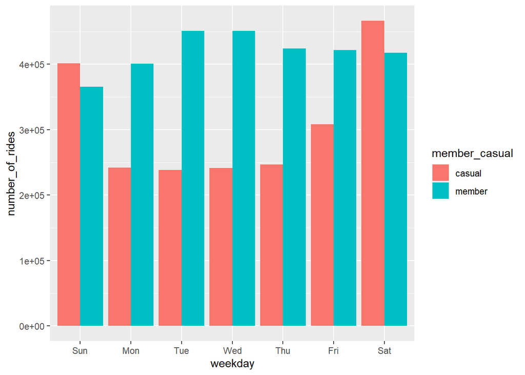

```r
all_trips_v2 %>%
  mutate(weekday = wday(started_at, label = TRUE)) %>%
  group_by(member_casual, weekday) %>%
  summarise(number_of_rides = n()
            ,average_duration = mean(ride_length)) %>%
  arrange(member_casual, weekday)  %>%
  ggplot(aes(x = weekday, y = number_of_rides, fill = member_casual)) +
  geom_col(position = "dodge")
```

Show average duration

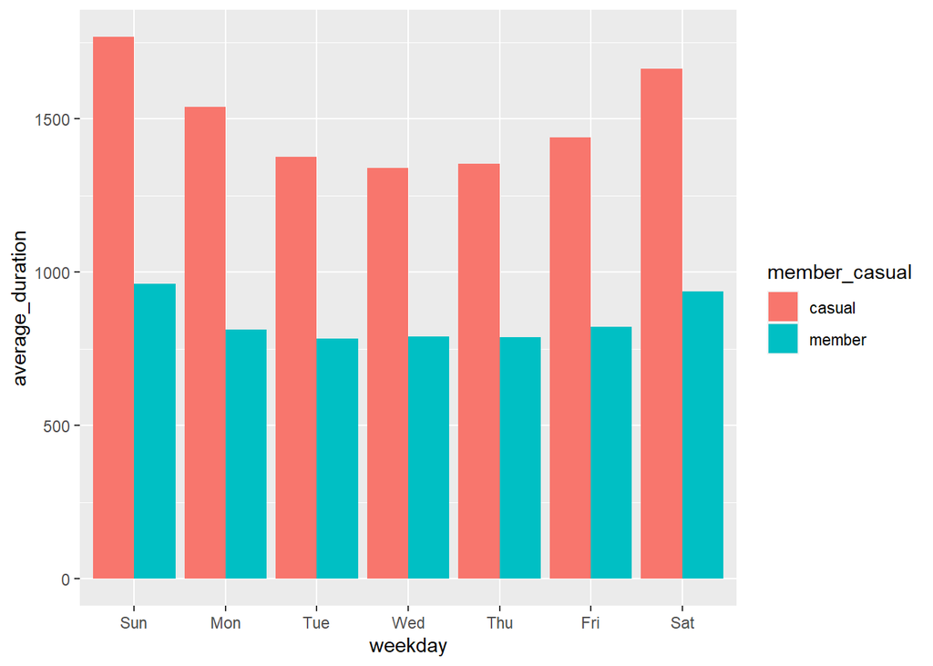

```r
all_trips_v2 %>%
  mutate(weekday = wday(started_at, label = TRUE)) %>%
  group_by(member_casual, weekday) %>%
  summarise(number_of_rides = n()
            ,average_duration = mean(ride_length)) %>%
  arrange(member_casual, weekday)  %>%
  ggplot(aes(x = weekday, y = average_duration, fill = member_casual)) +
  geom_col(position = "dodge")
```

Find only rides longer than one day per rider type

```r
long_trips <- all_trips_v2[(all_trips_v2$ride_length >= 86400),]
```

Show trips more than one day per rider type

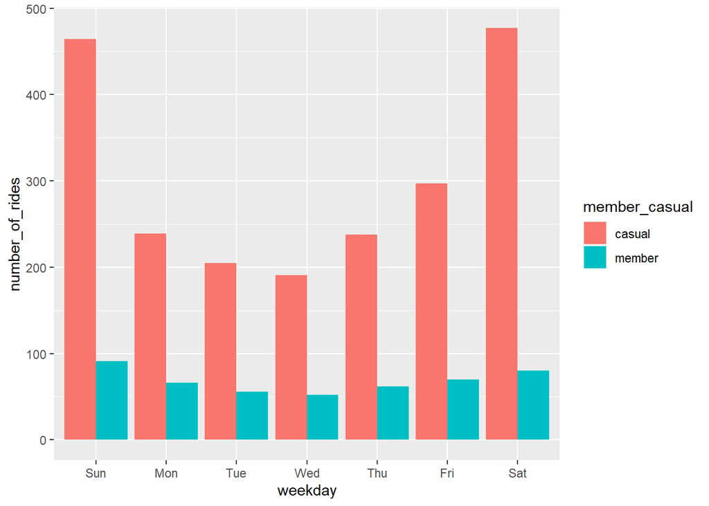

```r
long_trips %>%
  mutate(weekday = wday(started_at, label = TRUE)) %>%
  group_by(member_casual, weekday) %>%
  summarise(number_of_rides = n()
            ,average_duration = mean(ride_length)) %>%
  arrange(member_casual, weekday)  %>%
  ggplot(aes(x = weekday, y = number_of_rides, fill = member_casual)) +
  geom_col(position = "dodge")
```

Export summary files for further analysis

```r
counts <- aggregate(all_trips_v2$ride_length ~ all_trips_v2$member_casual + all_trips_v2$day_of_week, FUN = mean)
write.csv(counts, file = '~/avg_ride_length.csv')
```

```r
long_counts <- aggregate(long_trips$ride_length ~ long_trips$member_casual + long_trips$day_of_week, FUN = length)
write.csv(long_counts, file = '~/long_ride_length.csv')
```

```r
ride_counts <- aggregate(all_trips_v2$ride_length ~ all_trips_v2$member_casual + all_trips_v2$day_of_week, FUN = length)
write.csv(ride_counts, file = '~/number_of_rides.csv')
```